# Plata Risk Casebook — Six public-data studies

## Executive overview

Real UCI data: **30,000 clients**. The selected model is **hist_gradient_boosting**, chosen by development out-of-fold log loss. On the untouched grouped holdout (**6,006 clients**), ROC-AUC is **0.7820**, Gini **0.5640**, KS **0.4270**, Brier **0.1354**.

These are historical Taiwan default-payment results, not validation on Plata customers.

Under the explicit base scenario, total NPV is **-723,836,432 TWD**. The feasible limit strategy changes it by **195,212,799 TWD**. These monetary values are hypothetical scenario outputs, not observed profit.

## Context & Methods

A behavioral score uses information available through September 2005 to predict next-month default payment. No customer ID or outcome enters predictors. Sex and marital status are excluded; this does not establish fairness or legal suitability. Identical engineered-feature groups stay together through holdout, outer CV and inner calibration. Sigmoid calibration is fitted within training partitions. A grouped random split is not temporal validation.

### Key Assumptions

Economics uses TWD, constant monthly conditional hazard, fixed utilization and LGD; margins stop at default and losses occur at first default month-end. Annual compounding discounts monthly cash flows. This extrapolation of one-month default-payment scores is unvalidated. Limit response is an assumed odds elasticity, not causal evidence. All accounts remain open on the candidate grid. The optimizer returns a feasible solution with a dual gap bound, not an unqualified exact optimum.

```python
import json
import pandas as pd
from IPython.display import display, Image
from plata_risk.common import OUTPUTS, load_scores
scores, manifest = load_scores()
display(pd.Series(json.loads((OUTPUTS / 'case02_manifest.json').read_text())['assumptions'], name='Scenario assumptions'))
```

```
currency                                           TWD
horizon_months                                      12
annual_interest_rate                              0.24
annual_funding_rate                               0.08
annual_discount_rate                              0.12
monthly_servicing_cost                            30.0
acquisition_cost                                 500.0
lgd                                                0.6
utilization                                        0.4
hazard_assumption                     constant_monthly
limit_pd_odds_elasticity                          0.25
limit_multipliers               [0.75, 1.0, 1.25, 1.5]
risk_budget_ratio                                  1.0
frontier_budget_ratios      [0.9, 1.0, 1.05, 1.1, 1.2]
Name: Scenario assumptions, dtype: object
```

## Data

Source: I-Cheng Yeh, UCI Default of Credit Card Clients, [DOI 10.24432/C55S3H](https://doi.org/10.24432/C55S3H), CC BY 4.0. Raw archive and download SHA-256 are cached in `data/raw`. No synthetic data is used. Repayment codes absent from the source dictionary are retained as codes; negative bill balances are preserved. Education codes outside 1–4 are grouped as unknown.

```python
display(pd.Series(json.loads((OUTPUTS / 'case01_data_audit.json').read_text()), name='Data audit'))
display(scores[['customer_id', 'LIMIT_BAL', 'pd_1m', 'prediction_type']].head())
```

```
rows                                                                  30000
source_features                                                          23
missing_cells                                                             0
default_count                                                          6636
development_rows                                                      23994
holdout_rows                                                           6006
duplicate_feature_rows                                                  124
negative_bill_cells                                                    3932
education_codes           {'2': 14030, '1': 10585, '3': 4917, '5': 280, ...
repayment_codes                         [-2, -1, 0, 1, 2, 3, 4, 5, 6, 7, 8]
group_overlap                                                             0
excluded_predictors                   [customer_id, default, SEX, MARRIAGE]
scope                     Taiwan 2005 behavioral default-payment predict...
validation                Grouped random holdout, not out-of-time valida...
Name: Data audit, dtype: object
```

|  | customer_id | LIMIT_BAL | pd_1m | prediction_type |
| --- | --- | --- | --- | --- |
| 0 | 1 | 20000 | 0.657401 | out_of_fold |
| 1 | 2 | 120000 | 0.373914 | out_of_fold |
| 2 | 3 | 90000 | 0.102765 | out_of_fold |
| 3 | 4 | 50000 | 0.203153 | out_of_fold |
| 4 | 5 | 50000 | 0.066612 | out_of_fold |

## Results

### Credit risk discrimination and calibration

Only holdout results estimate out-of-sample performance after model selection. Development OOF metrics were used for selection and are not independent final estimates. Average precision and trapezoidal PR-AUC are reported separately.

|  | model | split | roc_auc | gini | ks | average_precision | pr_auc_trapezoid | brier | log_loss | n | default_rate |
| --- | --- | --- | --- | --- | --- | --- | --- | --- | --- | --- | --- |
| 0 | logistic | development_oof | 0.75464 | 0.50928 | 0.40178 | 0.51180 | 0.51159 | 0.14115 | 0.44761 | 23994 | 0.22156 |
| 1 | hist_gradient_boosting | development_oof | 0.78583 | 0.57165 | 0.43033 | 0.56670 | 0.56662 | 0.13282 | 0.42445 | 23994 | 0.22156 |
| 2 | logistic | holdout | 0.75269 | 0.50537 | 0.40357 | 0.50656 | 0.50578 | 0.14098 | 0.44771 | 6006 | 0.21978 |
| 3 | hist_gradient_boosting | holdout | 0.78201 | 0.56401 | 0.42698 | 0.54180 | 0.54138 | 0.13535 | 0.42934 | 6006 | 0.21978 |

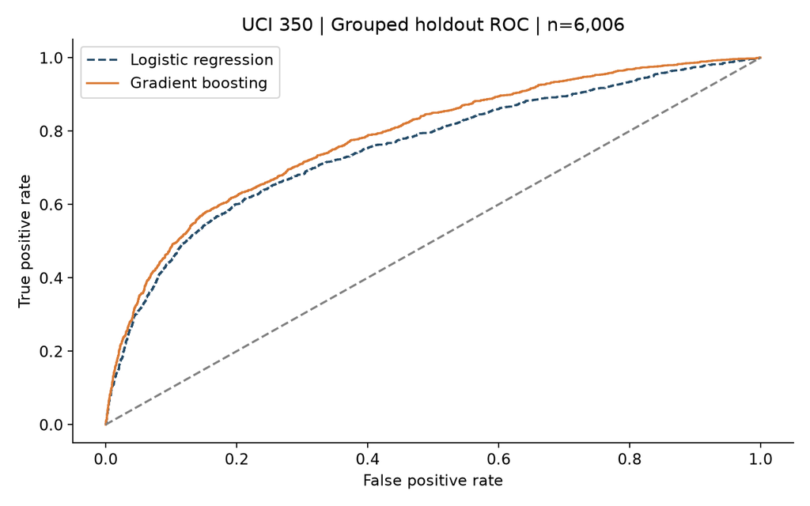

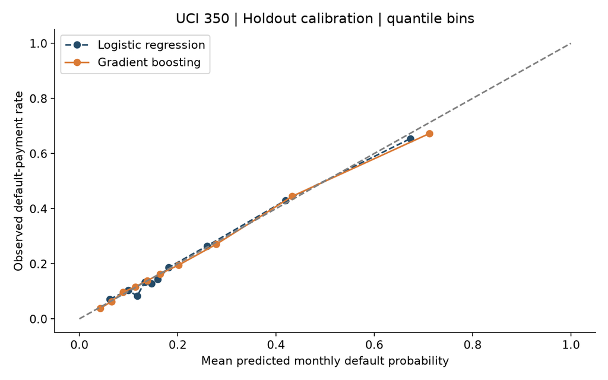

```python
display(pd.read_csv(OUTPUTS / 'case01_model_metrics.csv').round(5))
display(Image(filename=str(OUTPUTS / 'case01_roc.png')))
display(Image(filename=str(OUTPUTS / 'case01_calibration.png')))
```

### Risk deciles

Decile 10 contains the highest predicted risk. Stable rank tie-breaking creates ten near-equal-count bins; observed default rates remain holdout-only.

|  | decile | n | defaults | observed_rate | mean_pd |
| --- | --- | --- | --- | --- | --- |
| 0 | 1 | 601 | 23 | 0.0383 | 0.0429 |
| 1 | 2 | 601 | 38 | 0.0632 | 0.0656 |
| 2 | 3 | 600 | 58 | 0.0967 | 0.0891 |
| 3 | 4 | 601 | 70 | 0.1165 | 0.1137 |
| 4 | 5 | 600 | 83 | 0.1383 | 0.1378 |
| 5 | 6 | 601 | 98 | 0.1631 | 0.1643 |
| 6 | 7 | 600 | 117 | 0.1950 | 0.2018 |
| 7 | 8 | 601 | 163 | 0.2712 | 0.2779 |
| 8 | 9 | 600 | 266 | 0.4433 | 0.4329 |
| 9 | 10 | 601 | 404 | 0.6722 | 0.7117 |

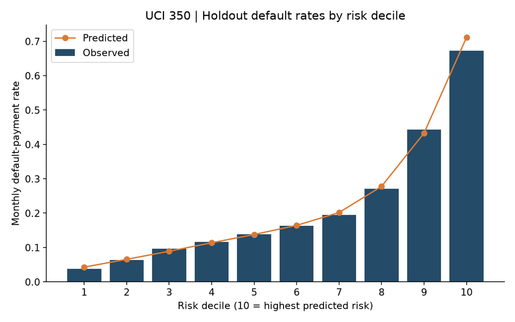

```python
display(pd.read_csv(OUTPUTS / 'case01_risk_deciles.csv').round(4))
display(Image(filename=str(OUTPUTS / 'case01_default_by_decile.png')))
```

### Scenario economics and limit strategy

The monetary sensitivity table varies assumptions; it is not a confidence interval. A negative NPV is retained as a finding under the assumptions, without changing rates to manufacture profitability. Chosen multipliers: 30,000 accounts at 0.75×. All configured feasible budgets give the same point; the data do not demonstrate a nontrivial risk-budget trade-off under these assumptions.

|  | lgd | annual_interest_rate | total_npv_twd |
| --- | --- | --- | --- |
| 0 | 0.4 | 0.18 | -4.949459e+08 |
| 1 | 0.4 | 0.24 | -4.407307e+08 |
| 2 | 0.4 | 0.30 | -3.865155e+08 |
| 3 | 0.6 | 0.18 | -7.780516e+08 |
| 4 | 0.6 | 0.24 | -7.238364e+08 |
| 5 | 0.6 | 0.30 | -6.696212e+08 |
| 6 | 0.8 | 0.18 | -1.061157e+09 |
| 7 | 0.8 | 0.24 | -1.006942e+09 |
| 8 | 0.8 | 0.30 | -9.527269e+08 |

|  | budget_ratio | budget_twd | feasible | expected_loss_twd | npv_twd | shadow_price | dual_upper_bound_twd | absolute_gap_bound_twd |
| --- | --- | --- | --- | --- | --- | --- | --- | --- |
| 0 | 0.90 | 7.962255e+08 | True | 6.477273e+08 | -5.286236e+08 | 0.0 | -5.286236e+08 | 0.0 |
| 1 | 1.00 | 8.846950e+08 | True | 6.477273e+08 | -5.286236e+08 | 0.0 | -5.286236e+08 | 0.0 |
| 2 | 1.05 | 9.289298e+08 | True | 6.477273e+08 | -5.286236e+08 | 0.0 | -5.286236e+08 | 0.0 |
| 3 | 1.10 | 9.731645e+08 | True | 6.477273e+08 | -5.286236e+08 | 0.0 | -5.286236e+08 | 0.0 |
| 4 | 1.20 | 1.061634e+09 | True | 6.477273e+08 | -5.286236e+08 | 0.0 | -5.286236e+08 | 0.0 |

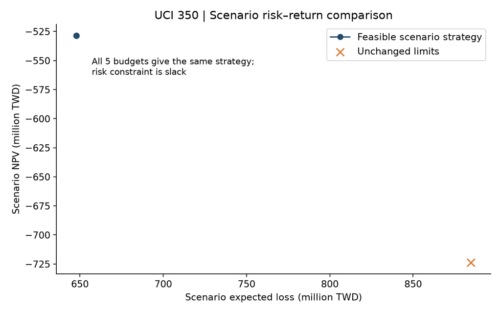

```python
display(pd.read_csv(OUTPUTS / 'case02_sensitivity.csv').round(2))
display(pd.read_csv(OUTPUTS / 'case03_risk_return_frontier.csv').round(2))
display(Image(filename=str(OUTPUTS / 'case03_frontier.png')))
```

## Takeaways

The three cases share verified customer IDs and hashed artifacts. Economics consumes out-of-fold predictions for development customers and holdout predictions for the reserved customers. Prediction models differ across folds, so portfolio scores are research estimates, not a deployed single-model portfolio.

Before real decisions: obtain current representative data, validate over time, evaluate fairness, estimate actual costs and recovery timing, and identify a causal limit-response model. No production credit decisions are justified by these historical experiments.

## Evaluation uncertainty and subgroup diagnostics

The 95% intervals resample identical-feature groups in the holdout with the fitted model fixed (500 draws). They do not capture retraining uncertainty or future population drift. Subgroup metrics describe this sample; they are not a fairness certification.

```python
display(pd.read_csv(OUTPUTS / 'case01_uncertainty.csv'))
display(pd.read_csv(OUTPUTS / 'case01_subgroups.csv'))
display(pd.read_csv(OUTPUTS / 'case02_horizon_comparison.csv'))
```

|  | metric | estimate | ci_low | ci_high | draws | method |
| --- | --- | --- | --- | --- | --- | --- |
| 0 | roc_auc | 0.782006 | 0.766942 | 0.796462 | 500 | feature-group percentile bootstrap; fixed fitt... |
| 1 | brier | 0.135352 | 0.129619 | 0.140821 | 500 | feature-group percentile bootstrap; fixed fitt... |

|  | feature | group | n | observed_rate | mean_pd | brier | roc_auc |
| --- | --- | --- | --- | --- | --- | --- | --- |
| 0 | SEX | 1 | 2378 | 0.252313 | 0.239707 | 0.148403 | 0.785031 |
| 1 | SEX | 2 | 3628 | 0.198456 | 0.213351 | 0.126797 | 0.777159 |
| 2 | AGE | [0.0, 30.0) | 1926 | 0.226376 | 0.231427 | 0.137745 | 0.784395 |
| 3 | AGE | [30.0, 45.0) | 2981 | 0.205636 | 0.208440 | 0.130164 | 0.780351 |
| 4 | AGE | [45.0, 60.0) | 1023 | 0.241447 | 0.248779 | 0.143032 | 0.779501 |
| 5 | AGE | [60.0, inf) | 76 | 0.315789 | 0.295716 | 0.174778 | 0.761218 |

|  | scenario | horizon_months | acquisition_cost | total_npv_twd | total_expected_loss_twd |
| --- | --- | --- | --- | --- | --- |
| 0 | existing_account_one_month | 1 | 0.0 | -1.857669e+08 | 2.089826e+08 |
| 1 | original_twelve_month_stress | 12 | 500.0 | -7.238364e+08 | 8.846950e+08 |

## Case 04 — Campaign response and scenario economics

[UCI Bank Marketing](https://doi.org/10.24432/C5K306), 45,211 records. The final 20% in source date order is held out. Model selection uses the preceding 20%; calibration uses expanding windows with matching-feature groups removed from training. Duration and current-campaign fields are excluded. Customer IDs and exact dates are unavailable. The selected model shows weak ranking and substantial probability drift on the later holdout. This is a limitation to investigate, not a deployment recommendation. Historical response among contacted customers cannot identify incremental campaign uplift. EUR economics is illustrative.

|  | model | split | roc_auc | gini | ks | average_precision | pr_auc_trapezoid | brier | log_loss | n | subscription_rate |
| --- | --- | --- | --- | --- | --- | --- | --- | --- | --- | --- | --- |
| 0 | logistic | ordered_validation | 0.463146 | -0.073708 | 0.002284 | 0.107563 | 0.107264 | 0.107278 | 0.386506 | 9000 | 0.117889 |
| 1 | hist_gradient_boosting | ordered_validation | 0.579410 | 0.158821 | 0.117661 | 0.154923 | 0.154403 | 0.107031 | 0.384209 | 9000 | 0.117889 |
| 2 | hist_gradient_boosting | ordered_holdout | 0.592325 | 0.184650 | 0.144216 | 0.377175 | 0.376833 | 0.268869 | 0.839888 | 9043 | 0.315824 |
| 3 | development_prevalence_baseline | ordered_holdout | 0.500000 | 0.000000 | 0.000000 | 0.315824 | 0.657912 | 0.277770 | 0.899367 | 9043 | 0.315824 |

|  | policy | contacts | observed_subscriptions | observed_rate | model_expected_net_eur | retrospective_net_proxy_eur |
| --- | --- | --- | --- | --- | --- | --- |
| 0 | Top 100% | 9043 | 2856 | 0.315824 | 56295.295635 | 267514.0 |
| 1 | Top 50% | 4522 | 1706 | 0.377267 | 33887.496302 | 161556.0 |
| 2 | Top 30% | 2713 | 1077 | 0.396978 | 22166.463789 | 102274.0 |
| 3 | Top 20% | 1809 | 757 | 0.418463 | 15656.355498 | 72082.0 |
| 4 | Top 10% | 905 | 366 | 0.404420 | 8548.172082 | 34790.0 |
| 5 | Positive scenario EV | 9043 | 2856 | 0.315824 | 56295.295635 | 267514.0 |

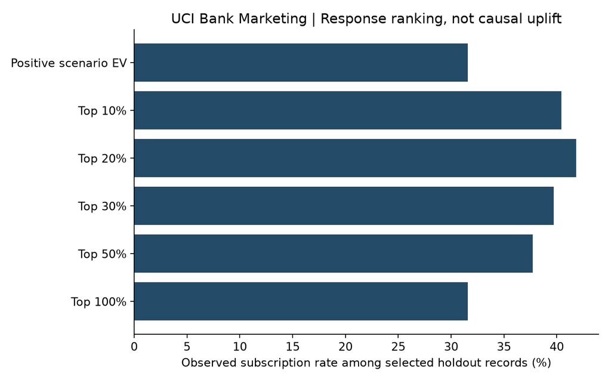

```python
display(pd.read_csv(OUTPUTS / 'case04_metrics.csv'))
display(pd.read_csv(OUTPUTS / 'case04_policies.csv'))
display(Image(filename=str(OUTPUTS / 'case04_policy_response.png')))
```

## Case 05 — Randomized email experiment

[Hillstrom research challenge](https://blog.minethatdata.com/2008/03/minethatdata-e-mail-analytics-and-data.html), 64,000 customers assigned to two email arms or no email. Intent-to-treat outcomes cover two weeks. Welch intervals are pointwise; Holm p-values adjust six comparisons. Contribution margin and email cost are explicit USD scenario assumptions. Baseline balance supports diagnostics but does not prove assignment integrity.

|  | segment | n | visit_rate | conversion_rate | mean_spend_usd |
| --- | --- | --- | --- | --- | --- |
| 0 | Mens E-Mail | 21307 | 0.182757 | 0.012531 | 1.422617 |
| 1 | No E-Mail | 21306 | 0.106167 | 0.005726 | 0.652789 |
| 2 | Womens E-Mail | 21387 | 0.151400 | 0.008837 | 1.077202 |

|  | arm | outcome | n_treatment | n_control | effect | se | ci_low | ci_high | p_value | p_holm | significant_holm |
| --- | --- | --- | --- | --- | --- | --- | --- | --- | --- | --- | --- |
| 0 | Mens E-Mail | visit | 21307 | 21306 | 0.076590 | 0.003386 | 0.069953 | 0.083226 | 1.364451e-112 | 8.186707e-112 | True |
| 1 | Mens E-Mail | conversion | 21307 | 21306 | 0.006805 | 0.000921 | 0.005000 | 0.008610 | 1.501816e-13 | 6.007263e-13 | True |
| 2 | Mens E-Mail | spend | 21307 | 21306 | 0.769827 | 0.145247 | 0.485140 | 1.054515 | 1.163815e-07 | 3.491445e-07 | True |
| 3 | Womens E-Mail | visit | 21387 | 21306 | 0.045233 | 0.003234 | 0.038893 | 0.051573 | 2.432448e-44 | 1.216224e-43 | True |
| 4 | Womens E-Mail | conversion | 21387 | 21306 | 0.003111 | 0.000823 | 0.001499 | 0.004724 | 1.560284e-04 | 3.120568e-04 | True |
| 5 | Womens E-Mail | spend | 21387 | 21306 | 0.424412 | 0.130333 | 0.168957 | 0.679868 | 1.129397e-03 | 1.129397e-03 | True |

|  | arm | outcome | n_treatment | n_control | effect | se | ci_low | ci_high | p_value | p_holm | significant_holm | net_contribution_effect | net_contribution_ci_low | net_contribution_ci_high |
| --- | --- | --- | --- | --- | --- | --- | --- | --- | --- | --- | --- | --- | --- | --- |
| 0 | Mens E-Mail | spend | 21307 | 21306 | 0.769827 | 0.145247 | 0.485140 | 1.054515 | 1.163815e-07 | 3.491445e-07 | True | 0.257931 | 0.144056 | 0.371806 |
| 1 | Womens E-Mail | spend | 21387 | 21306 | 0.424412 | 0.130333 | 0.168957 | 0.679868 | 1.129397e-03 | 1.129397e-03 | True | 0.119765 | 0.017583 | 0.221947 |

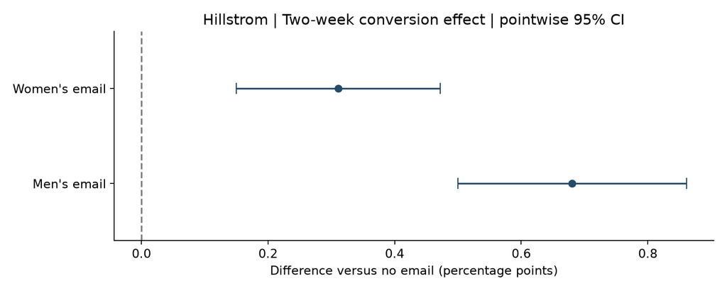

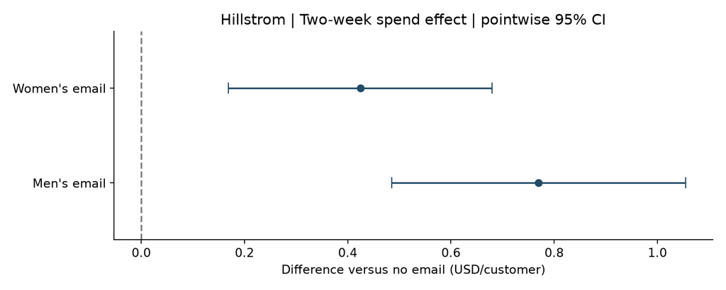

```python
display(pd.read_csv(OUTPUTS / 'case05_arm_summary.csv'))
display(pd.read_csv(OUTPUTS / 'case05_ate.csv'))
display(pd.read_csv(OUTPUTS / 'case05_email_economics.csv'))
display(Image(filename=str(OUTPUTS / 'case05_conversion_effect.png')))
display(Image(filename=str(OUTPUTS / 'case05_spend_effect.png')))
```

## Case 06 — Vintage monitoring with terminal outcomes

[Original LendingClub archive](https://resources.lendingclub.com/LoanStats3a.csv.zip), 2007–2011 originations. Exclude the explicitly identified non-policy loans. Only cohorts with at least 100 loans and 95% terminal coverage receive a reported rate. This undated snapshot supports terminal charge-off proportions; it does not support fixed-horizon default probabilities or observed month-to-month roll rates. A separate tested roll-rate function is provided for a future true loan-month panel.

```
status                                                               success
finished_at                                 2026-10-01T10:49:38.897894+00:00
source                     {'url': 'https://resources.lendingclub.com/Loa...
source_rows                                                            42535
policy_excluded_rows                                                    2749
analyzed_rows                                                          39786
terminal_rows                                                          39786
charged_off_rows                                                        5670
terminal_chargeoff_rate                                             0.142512
origination_from                                                  2007-06-01
origination_to                                                    2011-12-01
cohort_count                                                              55
eligible_cohort_count                                                     42
assumptions                {'terminal_statuses': ['Fully Paid', 'Charged ...
results_sha256             53d869e9e4d8432820d971c1d7c2f801026518618f8246...
caveat                     Lifetime terminal status at an undated source ...
dtype: object
```

|  | grade | n | originated_usd | bad_n | terminal_n | mean_interest_rate | terminal_chargeoff_rate |
| --- | --- | --- | --- | --- | --- | --- | --- |
| 0 | A | 10085 | 86982400.0 | 602 | 10085 | 0.073353 | 0.059693 |
| 1 | B | 12035 | 133872900.0 | 1433 | 12035 | 0.110216 | 0.119069 |
| 2 | C | 8111 | 89358850.0 | 1356 | 8111 | 0.135536 | 0.167180 |
| 3 | D | 5325 | 65438225.0 | 1130 | 5325 | 0.157234 | 0.212207 |
| 4 | E | 2858 | 45373750.0 | 725 | 2858 | 0.177173 | 0.253674 |
| 5 | F | 1054 | 19378100.0 | 323 | 1054 | 0.197530 | 0.306452 |
| 6 | G | 318 | 6446675.0 | 101 | 318 | 0.213953 | 0.317610 |

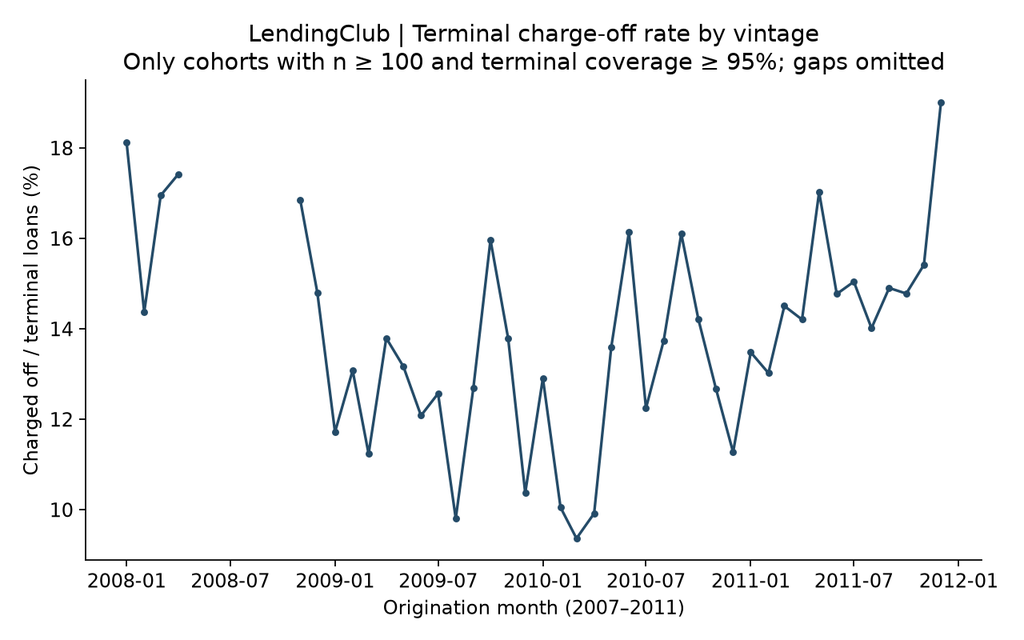

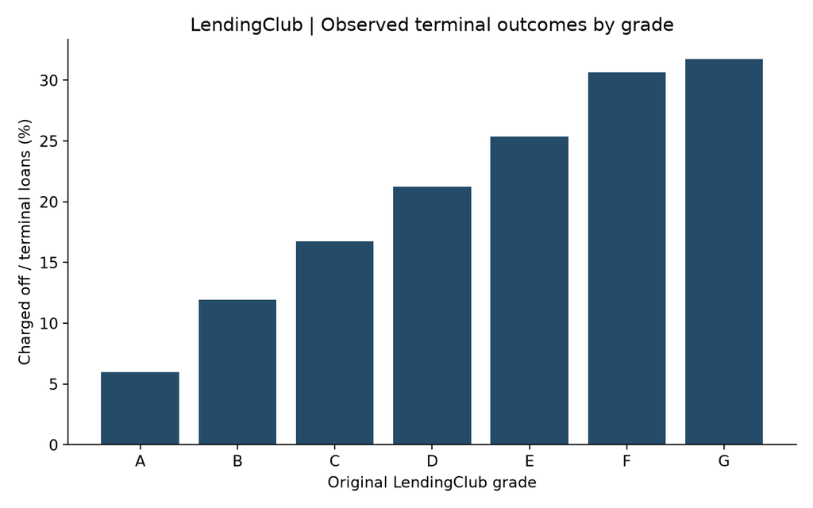

```python
display(pd.Series(json.loads((OUTPUTS / 'case06_manifest.json').read_text())))
display(pd.read_csv(OUTPUTS / 'case06_grade_summary.csv'))
display(Image(filename=str(OUTPUTS / 'case06_vintages.png')))
display(Image(filename=str(OUTPUTS / 'case06_grades.png')))
```

## Reproduction and evidence

Run Docker Compose with Python 3.12 and PostgreSQL 16. The pipeline, independent source reconciliation, transactional SQL loaders and this executable notebook form the evidence trail. Cases 01–03 share customer IDs and predecessor hashes. Cases 04–06 are distinct populations and are not joined to UCI credit clients. Sources and code are cited in the repository; no private Plata data, bank pricing or measured bank profit is claimed.